# Como sinais multimodais influenciam o tempo até o início do amplexo?

Daniel YM Nakamura e Jennifer P Auler

2022-11-08

# 1 Introdução

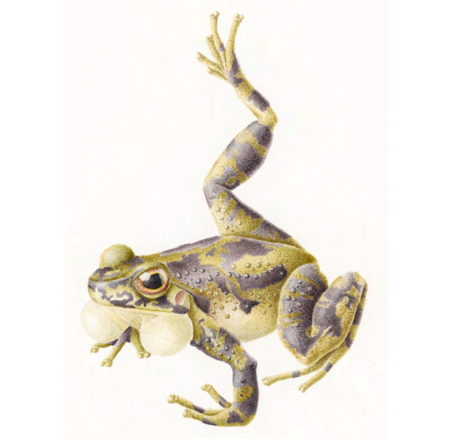

Figura 1: Ilustração de rã-de-corredeira (Hylodidae: Hylodes asper). Fonte: Paulo Presti.

Em anuros, o canto de anúncio é aquele emitido por machos para atrair fêmeas ou repelir machos competidores na paisagem acústica (Wells 1977; Duellman & Trueb 1986). A maioria das espécies de anuros apresentam comportamento noturno e portanto são altamente dependentes do canto para se reproduzirem. Contudo, na espécie *Hylodes asper* (Anura: Hylodidae) os machos apresentam comportamento diurno, sedentário e esperam até as fêmeas chegarem nos sítios reprodutivos, onde cantam em superfícies de rochas próximas a águas lóticas (i.e. rios de correnteza intensa ou cachoeiras; Heyer et al. 1990; Haddad & Giaretta 1999). Devido à disponibilidade de luz e ao ruído de fundo das correntezas, sinais visuais podem ser apresentados concomitantemente aos sinais acústicos para maximizar a transmissão de informação entre o macho emissor e as fêmeas ou machos receptores (Hödl et al. 1997). Embora a maioria dos estudos utilize aspectos temporais (e.g. taxa de cantos) ou espectrais (i.e. o quão agudo ou grave o canto é) como variáveis respostas de modelos (e.g. Gingras et al. 2013; Goutte et al. 2016), o tempo em que as fêmeas demoram para chegar nos sítios reprodutivos e iniciarem o amplexo é pouco estudado.

Existem sinais multimodais compostos por características morfológicas, acústicas e visuais que são consideradas mais atrativas pelas fêmeas e podem explicar o tempo até sua chegada e início do amplexo. Por exemplo, uma possível preditora acústica é a **frequência dominante** do canto (DF: a banda com maior concentração de energia no espectro; Köhler et al. 2017), no qual cantos mais graves são considerados mais atrativos e talvez reduzam o tempo até o início do amplexo, pois machos com canto mais grave geralmente tem cordas vocais mais espessas e compridas (McClelland et al. 1996), o que geralmente é um sinal honesto que informa o tamanho corporal do macho (Wells 2007; Köhler et al. 2017). Contudo, existem machos que mentem! Machos mentirosos são comuns em algumas espécies, os quais conseguem modular a frequência do canto (i.e. deixar mais grave por relaxamento dos músculos da cartilagem aritenóide; Martin 1971; Schmid 1979; Ryan 1988). Por isso, incluir o **tamanho corporal** como uma variável preditora é uma forma de avaliar a honestidade da frequência. Por fim, machos da espécie *Hylodes asper* às vezes cantam ao mesmo tempo em que apresentam um display visual chamado *foot-flagging*, no qual esticam as pernas para chamarem atenção das fêmeas visualmente devido ao barulho das corredeiras que podem reduzir as chances de serem escutados pelas fêmeas (Heyer et al. 1990; Haddad & Giaretta 1999). Portanto, uma última hipótese é que uma taxa de foot-flagging alta reduza o tempo até as fêmeas iniciarem o amplexo.

# 2 Objetivos e hipóteses

O objetivo geral desse trabalho é responder como sinais multi-modais influenciam o tempo até o início do amplexo em *Hylodes asper*. Os objetivos específicos são entender:

1. Como os sinais espectrais de frequência dominante (DF) influenciam o tempo até o início do amplexo?
- H0: Não há influência da DF sobre o tempo até o início do amplexo
- H1: DF é positivamente relacionada com o tempo até o início do amplexo, de modo que machos com canto mais grave (menor DF) copulam antes (menor tempo até o início do amplexo)
2. Como o tamanho corporal influencia o tempo até o início do amplexo?
- H0: Não há influência do tamanho corporal sobre o tempo até o início do amplexo
- H1: Tamanho corporal é negativamente relacionada com o tempo até o início do amplexo, de modo que machos maiores copulam antes
3. Como os sinais visuais de taxa de *foot-flagging* influenciam o tempo até o início do amplexo?
- H0: Não há influência da taxa de *foot-flagging* sobre o tempo até o início do amplexo
- H1: Taxa de *foot-flagging* é negativamente relacionada com o tempo até o início do amplexo, de modo que machos que dançam mais copulam antes

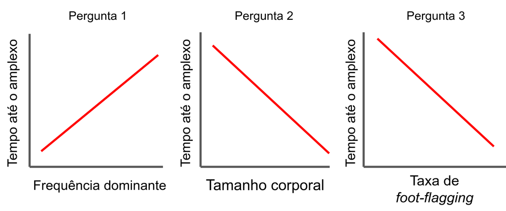

Figura 2: Predições para as perguntas do trabalho. Espera-se uma (I) relação positiva entre frequência dominante (DF) e tempo até o amplexo, (II) relação negativa entre tamanho corporal e tempo até o amplexo, e (III) relação negativa entre taxa de foot-flagging e tempo até o amplexo.

# 3 Simulação de dados

Embora dados das nossas variáveis preditoras sejam mais acessíveis na literatura, dados da nossa variável resposta (tempo de espera da fêmea até início da cópula) são escassos. Isso ocorre pois é extremamente custoso ao biólogo de campo tentar localizar uma fêmea de anuro próxima dos machos já que elas não cantam e raramente são vistas na natureza. Portanto, optamos pelo uso de dados simulados.

As nossas variáveis preditoras teóricas são frequência do canto, tamanho corporal e *display* de *foot-flagging*. Contudo, precisamos operacionalizar essas variáveis. Utilizamos as seguintes variáveis preditoras operacionais:

- Frequência dominante (DF: medida em Hz), definida como a frequência no espectro harmônico com maior concentração de energia que é percebida pelo ouvido humano como o quão grave ou agudo os sons são (Köhler et al. 2017);
- Comprimento rostro-cloacal (SVL: *snout-vent length*, medida em mm), o qual é amplamente usado como aproximação do tamanho corporal pois mede o comprimento da extremedidade anterior do focinho até a extremidade posterior da cloaca (Duellman 1970);
- Taxa de *foot-flagging* (medida em número de eventos/minuto).

Para *Hylodes asper*, Haddad & Giaretta (1999) reportaram que a DF se encontra no terceiro harmônico entre 5000 a 6500 Hz, com valor de *midpoint* ([máx - min] / 2) igual a 5750 Hz. Heyer et al. (1990) reportaram que os machos apresentam um SVL médio de 40.5 mm (39.4-42.3 mm). Já a taxa de *foot-flagging* não foi reportada por unidade de tempo em nenhum destes trabalhos, mas é possível estimar através de vídeos disponíveis no YouTube (~10 a cada 5 min). Utilizamos estes valores como referência das características dos machos simulados na função ‘saposim’.

```r
source("R/funcoes_auxiliares.R")
source("R/saposim.R")
```

A cada simução é criada uma nova matriz de `espaco` de `area` linhas e `area` colunas. Em seguida, são sorteadas as posições dos `nmacho` daquela simulação. A frequência dominante do canto `freq` (DF: Hz), taxa de *foot-flagging* `foot` (número de eventos de *foot-flagging*/minuto) e tamanho corporal `tama` (SVL: mm) de cada um dos machos é simulada. Estas caracteristicas são sorteadas a partir de uma distribuição (normal, poisson e normal para DF, taxa de *foot-flagging* e SVL, respectivamente) e, em seguida, padronizadas pela função `padroniza`. Os valores padronizados aparecem no output como `freqpad`, `footpad` e `tamapad`. É esperado que machos mais próximos à cachoeira tenham menor tamanho corporal (SVL menor) e vocalizem em frequencias mais agudas (DF maior) e portanto tenham, em média, probabilidade menor de atrair fêmeas. No entanto, é esperado que esses machos tenham também maior taxa de *foot-flagging*, o que pode contra-balancear essa esperança. Apesar de estes valores serem correlacionados, as características do macho são sorteadas independentemente de uma distribuição aleatória.

Todos os machos ficam parados, sem mudarem os sítios reprodutivos, pois eles são altamente territoriais. Portanto, apenas a fêmea se locomove.

A probabilidade de seleção do macho é então calculada através de uma regressão logistica,
$$P =
\frac{e^{exprlin}}{1+e^{exprlin}}$$
com expressão linear de fórmula: $exprlin = a \times tamanho + b \times taxafootflag + c \times DF$ e intercepto igual à média da expressão linear.

Uma cédula vazia é então sorteada para a fêmea ocupar, e esta escolhe um macho para copular com probabilidade `prob`. A distância `distf` entre a fêmea e o macho escolhido é calculada pela função `dist`. A fêmea e o macho são considerados ocupados até o final da simulação e são retirados do `espaco`. A simulação se repete com `nfemea = nmacho`. O tempo total `ttot` para o macho ser escolhido também é guardado, sendo definido como a soma de todas `distf` anteriores na mesma simulação. A função de simulação de sapos, `saposim` se encontra na íntegra no arquivo “R/saposim.R”.

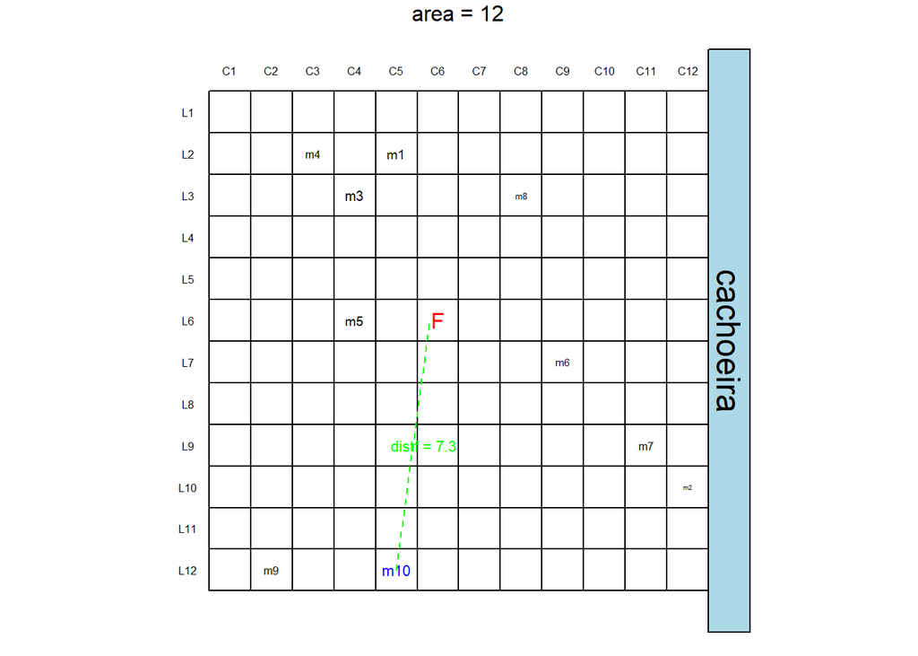

Figura 3 - Uma distribuição hipotética de machos (m1 a m10) e fêmea (F) no espaço. A probabilidade de seleção dos machos está representada pelo tamanho da fonte. Ao lado direito se encontra a cachoeira, que se correlaciona com a probabilidade de seleção. Neste exemplo, o macho “m10” foi escolhido e a sua distancia “distf” foi calculada.

Além do efeito das características dos sapos, decidimos também investigar se a variação na `area` da cachoeira é relevante para o tempo até o início do amplexo. Como resultado, apresentamos então quatro simulações:

- `sim_Avar` - dimensões da cachoeira (`area`) sorteada de uma distribuição uniforme entre 10 e 100 (arredondada para números inteiros).
- `sim_Afix10` - dimensões da cachoeira (`area`) fixa em 10.
- `sim_Afix50` - dimensões da cachoeira (`area`) fixa em 50.
- `sim_Afix100` - dimensões da cachoeira (`area`) fixa em 100.

Em ambas as simulações foram mantidas os valores padrão:

- `nsim` = 1000
- `vecarea = round(runif(nsim, 10, 100), 0)`
- `vecnmacho = vecarea`
- `cffreq` = 1.05
- `cftama` = -0.5
- `cffoot` = -0.8

O código das simulações está no documento “R/simula_dados.R”. Como `nsim` é grande e leva alguns minutos, salvamos o resultado das simulações como arquivos `R.data`.

```r
load("data/sim_Avar.Rdata")
load("data/sim_Afix10.Rdata")
load("data/sim_Afix50.Rdata")
load("data/sim_Afix100.Rdata")
```

Para exemplificar, as primeiras linhas do dataset simulado com área variada:

```r
head(sim_Avar)
```

```
##   machoid dcach foot     freq     tama    footpad   freqpad    tamapad  exprlin
## 1      m6    23    0 6073.249 41.23807 -0.6437072 1.6257241  0.4755348 1.984209
## 2     m13    18    2 5909.334 41.09104 -0.1830727 0.8921084  0.3894779 0.888433
## 3     m23    13    2 6054.715 38.35027 -0.1830727 1.5427735 -1.2147073 2.373724
## 4     m14    27    0 5898.983 40.15064 -0.6437072 0.8457784 -0.1609394 1.483503
## 5     m31    33    0 5741.797 38.31741 -0.6437072 0.1422817 -1.2339378 1.281330
## 6     m18    19    0 5885.569 38.97416 -0.6437072 0.7857457 -0.8495407 1.764769
##        prob    distf     ttot nsim femea area femeasim
## 1 0.8791291 23.76973 23.76973 sim1   f01   39 f01_sim1
## 2 0.7085667 17.26268 41.03241 sim1   f02   39 f02_sim1
## 3 0.9148016 11.04536 52.07777 sim1   f03   39 f03_sim1
## 4 0.8151011  3.00000 55.07777 sim1   f04   39 f04_sim1
## 5 0.7826762 28.31960 83.39737 sim1   f05   39 f05_sim1
## 6 0.8538059 15.81139 99.20876 sim1   f06   39 f06_sim1
```

**Sumário de sim_Avar**

```r
summary(sim_Avar)
```

```
##    machoid              dcach            foot             freq
##  Length:54637       Min.   : 0.00   Min.   : 0.000   Min.   :4851
##  Class :character   1st Qu.:13.00   1st Qu.: 0.000   1st Qu.:5566
##  Mode  :character   Median :29.00   Median : 0.000   Median :5701
##                     Mean   :32.84   Mean   : 1.909   Mean   :5700
##                     3rd Qu.:49.00   3rd Qu.: 3.000   3rd Qu.:5835
##                     Max.   :99.00   Max.   :21.000   Max.   :6519
##       tama          footpad           freqpad             tamapad
##  Min.   :31.29   Min.   :-2.3732   Min.   :-3.755707   Min.   :-4.03662
##  1st Qu.:39.05   1st Qu.:-0.5101   1st Qu.:-0.679097   1st Qu.:-0.67701
##  Median :40.41   Median :-0.4300   Median : 0.004467   Median : 0.00446
##  Mean   :40.40   Mean   : 0.0000   Mean   : 0.000000   Mean   : 0.00000
##  3rd Qu.:41.75   3rd Qu.: 0.1248   3rd Qu.: 0.675742   3rd Qu.: 0.67946
##  Max.   :47.99   Max.   : 5.6852   Max.   : 3.791400   Max.   : 4.12625
##     exprlin              prob             distf             ttot
##  Min.   :-6.59909   Min.   :0.00136   Min.   :  1.00   Min.   :   1.0
##  1st Qu.:-0.87396   1st Qu.:0.29443   1st Qu.: 18.03   1st Qu.: 369.6
##  Median : 0.08155   Median :0.52038   Median : 31.30   Median : 966.7
##  Mean   : 0.00000   Mean   :0.50646   Mean   : 34.70   Mean   :1298.0
##  3rd Qu.: 0.95826   3rd Qu.:0.72277   3rd Qu.: 48.27   3rd Qu.:1951.1
##  Max.   : 4.97946   Max.   :0.99317   Max.   :125.73   Max.   :5702.5
##      nsim              femea                area          femeasim
##  Length:54637       Length:54637       Min.   : 10.00   Length:54637
##  Class :character   Class :character   1st Qu.: 50.00   Class :character
##  Mode  :character   Mode  :character   Median : 70.00   Mode  :character
##                                        Mean   : 66.69
##                                        3rd Qu.: 85.00
##                                        Max.   :100.00
```

**Sumário de sim_Afix10**

```r
summary(sim_Afix10)
```

```
##    machoid              dcach          foot             freq
##  Length:10000       Min.   :0.0   Min.   : 0.000   Min.   :4970
##  Class :character   1st Qu.:2.0   1st Qu.: 6.000   1st Qu.:5566
##  Mode  :character   Median :4.5   Median : 7.000   Median :5701
##                     Mean   :4.5   Mean   : 7.752   Mean   :5700
##                     3rd Qu.:7.0   3rd Qu.:10.000   3rd Qu.:5833
##                     Max.   :9.0   Max.   :24.000   Max.   :6381
##       tama          footpad            freqpad             tamapad
##  Min.   :33.04   Min.   :-2.45077   Min.   :-2.610457   Min.   :-2.589721
##  1st Qu.:39.01   1st Qu.:-0.71151   1st Qu.:-0.692166   1st Qu.:-0.693774
##  Median :40.36   Median :-0.09278   Median :-0.007968   Median : 0.006792
##  Mean   :40.37   Mean   : 0.00000   Mean   : 0.000000   Mean   : 0.000000
##  3rd Qu.:41.71   3rd Qu.: 0.66192   3rd Qu.: 0.698879   3rd Qu.: 0.678290
##  Max.   :49.00   Max.   : 2.64677   Max.   : 2.675983   Max.   : 2.533804
##     exprlin               prob             distf             ttot
##  Min.   :-4.543709   Min.   :0.01052   Min.   : 1.000   Min.   : 1.00
##  1st Qu.:-0.894340   1st Qu.:0.29022   1st Qu.: 3.162   1st Qu.:14.98
##  Median :-0.003913   Median :0.49902   Median : 5.099   Median :27.88
##  Mean   : 0.000000   Mean   :0.50035   Mean   : 5.216   Mean   :28.63
##  3rd Qu.: 0.911340   3rd Qu.:0.71327   3rd Qu.: 7.071   3rd Qu.:41.32
##  Max.   : 4.659173   Max.   :0.99061   Max.   :12.728   Max.   :76.71
##      nsim              femea                area      femeasim
##  Length:10000       Length:10000       Min.   :10   Length:10000
##  Class :character   Class :character   1st Qu.:10   Class :character
##  Mode  :character   Mode  :character   Median :10   Mode  :character
##                                        Mean   :10
##                                        3rd Qu.:10
##                                        Max.   :10
```

**Sumário de sim_Afix50**

```r
summary(sim_Afix50)
```

```
##    machoid              dcach           foot             freq
##  Length:50000       Min.   : 0.0   Min.   : 0.000   Min.   :4907
##  Class :character   1st Qu.:12.0   1st Qu.: 0.000   1st Qu.:5563
##  Mode  :character   Median :24.5   Median : 0.000   Median :5698
##                     Mean   :24.5   Mean   : 2.087   Mean   :5699
##                     3rd Qu.:37.0   3rd Qu.: 4.000   3rd Qu.:5835
##                     Max.   :49.0   Max.   :21.000   Max.   :6529
##       tama          footpad           freqpad             tamapad
##  Min.   :32.41   Min.   :-0.6905   Min.   :-3.609588   Min.   :-3.664646
##  1st Qu.:39.05   1st Qu.:-0.6136   1st Qu.:-0.683317   1st Qu.:-0.676571
##  Median :40.40   Median :-0.5783   Median :-0.000998   Median :-0.001457
##  Mean   :40.40   Mean   : 0.0000   Mean   : 0.000000   Mean   : 0.000000
##  3rd Qu.:41.76   3rd Qu.: 0.4178   3rd Qu.: 0.683100   3rd Qu.: 0.678388
##  Max.   :48.79   Max.   : 4.7452   Max.   : 3.685079   Max.   : 3.870682
##     exprlin              prob              distf            ttot
##  Min.   :-6.09137   Min.   :0.002257   Min.   : 1.00   Min.   :   1.0
##  1st Qu.:-0.89095   1st Qu.:0.290913   1st Qu.:16.28   1st Qu.: 333.4
##  Median : 0.06208   Median :0.515515   Median :25.50   Median : 652.7
##  Mean   : 0.00000   Mean   :0.505083   Mean   :26.03   Mean   : 657.8
##  3rd Qu.: 0.95837   3rd Qu.:0.722794   3rd Qu.:35.13   3rd Qu.: 976.7
##  Max.   : 4.87114   Max.   :0.992394   Max.   :67.90   Max.   :1573.4
##      nsim              femea                area      femeasim
##  Length:50000       Length:50000       Min.   :50   Length:50000
##  Class :character   Class :character   1st Qu.:50   Class :character
##  Mode  :character   Mode  :character   Median :50   Mode  :character
##                                        Mean   :50
##                                        3rd Qu.:50
##                                        Max.   :50
```

**Sumário de sim_Afix100**

```r
summary(sim_Afix100) #arrumar dps pra rodar
```

```
##    machoid              dcach            foot             freq
##  Length:100000      Min.   : 0.00   Min.   : 0.000   Min.   :4883
##  Class :character   1st Qu.:24.75   1st Qu.: 0.000   1st Qu.:5564
##  Mode  :character   Median :49.50   Median : 0.000   Median :5699
##                     Mean   :49.50   Mean   : 1.045   Mean   :5700
##                     3rd Qu.:74.25   3rd Qu.: 0.000   3rd Qu.:5835
##                     Max.   :99.00   Max.   :21.000   Max.   :6608
##       tama          footpad           freqpad             tamapad
##  Min.   :31.99   Min.   :-0.4341   Min.   :-4.243236   Min.   :-3.98188
##  1st Qu.:39.05   1st Qu.:-0.4021   1st Qu.:-0.674822   1st Qu.:-0.67902
##  Median :40.41   Median :-0.3895   Median :-0.000945   Median : 0.00004
##  Mean   :40.41   Mean   : 0.0000   Mean   : 0.000000   Mean   : 0.00000
##  3rd Qu.:41.77   3rd Qu.:-0.3693   3rd Qu.: 0.678445   3rd Qu.: 0.67865
##  Max.   :49.73   Max.   : 6.6451   Max.   : 4.030381   Max.   : 4.03590
##     exprlin              prob               distf             ttot
##  Min.   :-7.92838   Min.   :0.0003602   Min.   :  1.00   Min.   :   1
##  1st Qu.:-0.82395   1st Qu.:0.3049266   1st Qu.: 32.98   1st Qu.:1300
##  Median : 0.08871   Median :0.5221632   Median : 51.20   Median :2587
##  Mean   : 0.00000   Mean   :0.5084437   Mean   : 52.15   Mean   :2601
##  3rd Qu.: 0.94414   3rd Qu.:0.7199356   3rd Qu.: 70.26   3rd Qu.:3881
##  Max.   : 5.17291   Max.   :0.9943639   Max.   :133.69   Max.   :6065
##      nsim              femea                area       femeasim
##  Length:100000      Length:100000      Min.   :100   Length:100000
##  Class :character   Class :character   1st Qu.:100   Class :character
##  Mode  :character   Mode  :character   Median :100   Mode  :character
##                                        Mean   :100
##                                        3rd Qu.:100
##                                        Max.   :100
```

# 4 Resultados

**Por que usamos a distribuição Gamma**  
A distribuição Gamma é uma gereralização da distribuição exponencial e é uma boa opção para modelar o tempo até N eventos ocorrerem. Esta distribuição possui dois parâmetros: shape (k) e scale ($\theta$). Como nossa variável é o tempo até um determinado macho atingir amplexo, a distribuição Gammma é apropriada. É frequente que os GLMM Gamma sejam difícies de implementar, especialmente utilizando a função de ligação canônica `“inverse”` (Bolker at al 2022). Por esse motivo, alguns autores, como Lo e Andrews (2015) indicam utiliar a função de ligação `“log”`, a qual utilizaremos aqui.

Os seguintes pacotes foram utilizados para as análises estatísticas e plotagem:

```r
library(AICcmodavg)
library(ggplot2)
library(gridExtra)
library(lme4)
library(MASS)
library(bbmle)
library(interactions)
library(tibble)
library(tidyverse)
library(broom)
library(multcomp)
```

## 4.1 Simulação com área fixa

### 4.1.1 Área fixa em 10

#### 4.1.1.1 Análise exploratória

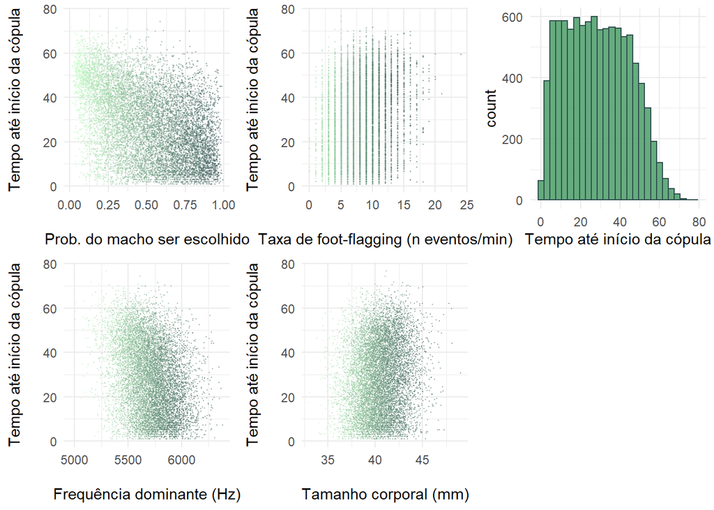

```r
AED(sim_Afix10, binw = 3)
```

#### 4.1.1.2 Seleção de modelos

Optamos pelo uso de modelos generalizados mistos, pois pode haver um efeito aleatório de cada rio (a variação entre rios pode ser maior do que a variação dentro de um mesmo rio). Além disso, optamos por utilizar a distribuição Gama, pois estamos interessados no tempo até a fêmea escolher um macho e iniciar o amplexo.

**Modelos com área fixa em 10**

```r
# 1. GLMM Cheio: efeito aleatório das cachoeiras sobre o intercepto + efeito fixo com tripla interação

glmm10.1 = glmer(ttot~tamapad*freqpad*footpad + (1|nsim), family=Gamma(link = "log"), data=sim_Afix10)

# 2. GLMM sem tripla
glmm10.2 = glmer(ttot~tamapad+freqpad+footpad+tamapad:freqpad+tamapad:footpad+freqpad:footpad + (1|nsim), family=Gamma(link = "log"), data=sim_Afix10)

# 3. GLMM sem 1 dupla: freqpad:footpad
glmm10.3 = glmer(ttot~tamapad+freqpad+footpad+tamapad:freqpad+tamapad:footpad + (1|nsim), family=Gamma(link = "log"), data=sim_Afix10)

# 4. GLMM sem 1 dupla: tamapad:footpad
glmm10.4 = glmer(ttot~tamapad+freqpad+footpad+tamapad:freqpad+freqpad:footpad + (1|nsim), family=Gamma(link = "log"), data=sim_Afix10)

# 5. GLMM sem 1 dupla: tamapad:freqpad
glmm10.5 = glmer(ttot~tamapad+freqpad+footpad+tamapad:footpad+freqpad:footpad + (1|nsim), family=Gamma(link = "log"), data=sim_Afix10)

# 6. GLMM sem 2 duplas: freqpad:footpad e tamapad:footpad
glmm10.6 = glmer(ttot~tamapad+freqpad+footpad+tamapad:freqpad + (1|nsim), family=Gamma(link = "log"), data=sim_Afix10)

# 7. GLMM sem 2 duplas: tamapad:footpad e tamapad:freqpad
glmm10.7 = glmer(ttot~tamapad+freqpad+footpad+freqpad:footpad + (1|nsim), family=Gamma(link = "log"), data=sim_Afix10)

# 8. GLMM sem 2 duplas: freqpad:footpad e tamapad:freqpad
glmm10.8 = glmer(ttot~tamapad+freqpad+footpad+tamapad:footpad + (1|nsim), family=Gamma(link = "log"), data=sim_Afix10)

# 9. GLMM sem nenhuma dupla
glmm10.9 = glmer(ttot~tamapad+freqpad+footpad + (1|nsim), family=Gamma(link = "log"), data=sim_Afix10)

# 10. GLMM sem freqpad
glmm10.10 = glmer(ttot~tamapad+footpad + (1|nsim), family=Gamma(link = "log"), data=sim_Afix10)

# 11. GLMM sem footpad
glmm10.11 = glmer(ttot~tamapad+freqpad + (1|nsim), family=Gamma(link = "log"), data=sim_Afix10)

# 12. GLMM sem tamapad
glmm10.12 = glmer(ttot~freqpad+footpad + (1|nsim), family=Gamma(link = "log"), data=sim_Afix10)

# 13. GLMM só com freqpad
glmm10.13 = glmer(ttot~freqpad + (1|nsim), family=Gamma(link = "log"), data=sim_Afix10)

# 14. GLMM só com footpad
glmm10.14 = glmer(ttot~footpad + (1|nsim), family=Gamma(link = "log"), data=sim_Afix10)

# 15. GLMM só com tamapad
glmm10.15 = glmer(ttot~tamapad + (1|nsim), family=Gamma(link = "log"), data=sim_Afix10)
```

```r
# Seleção do Modelo
models10 = c(glmm10.1, glmm10.2, glmm10.3, glmm10.4, glmm10.5, glmm10.6, glmm10.7, glmm10.8, glmm10.9, glmm10.10, glmm10.11, glmm10.12, glmm10.13, glmm10.14, glmm10.15)
model.names10 = c("glmm10.1", "glmm10.2", "glmm10.3", "glmm10.4", "glmm10.5", "glmm10.6", "glmm10.7", "glmm10.8", "glmm10.9", "glmm10.10", "glmm10.11", "glmm10.12", "glmm10.13", "glmm10.14", "glmm10.15")
aictab(cand.set=models10, modnames=model.names10, refit=FALSE)
```

```
##
## Model selection based on AICc:
##
##            K     AICc Delta_AICc AICcWt Cum.Wt        LL
## glmm10.4   8 82257.88       0.00   0.14   0.14 -41120.93
## glmm10.6   7 82257.89       0.01   0.14   0.29 -41121.94
## glmm10.9   6 82258.23       0.35   0.12   0.41 -41123.11
## glmm10.7   7 82258.34       0.46   0.11   0.52 -41122.16
## glmm10.2   9 82258.36       0.48   0.11   0.64 -41120.17
## glmm10.3   8 82258.44       0.56   0.11   0.75 -41121.21
## glmm10.8   7 82258.67       0.79   0.10   0.84 -41122.33
## glmm10.5   8 82258.75       0.86   0.09   0.94 -41121.37
## glmm10.1  10 82259.49       1.61   0.06   1.00 -41119.74
## glmm10.12  5 82442.74     184.86   0.00   1.00 -41216.37
## glmm10.11  5 82808.37     550.49   0.00   1.00 -41399.18
## glmm10.13  4 82961.48     703.60   0.00   1.00 -41476.74
## glmm10.10  5 83195.81     937.93   0.00   1.00 -41592.90
## glmm10.14  4 83346.64    1088.76   0.00   1.00 -41669.32
## glmm10.15  4 83696.20    1438.31   0.00   1.00 -41844.10
```